# week_14

### PI and CI

the PI means under the confidence level of 95%,if we pick a y under x=specific, it will have the probability of 95% to be in the interval  
,also means 95% of population y might be in the interval,**y的可能範圍**

the CI means under the confidence level of 95%, if we sample a lot of time as x=specific and calculate a mean, the mean would have the probability of 95% to be in the interval  
**E(y)的可能範圍**

```r
#PI
PI=predict(RESULTS,data.frame(GDP=c(9000,13000,17000)),interval="prediction",level=0.95);PI
```

```
##       fit     lwr     upr
## 1 4355042 3980710 4729374
## 2 5577056 5206360 5947752
## 3 6799070 6413130 7185010
```

```r
#CI
CI=predict(RESULTS,data.frame(GDP=c(9000,13000,17000)),interval="confidence",level=0.95);CI
```

```
##       fit     lwr     upr
## 1 4355042 4263081 4447003
## 2 5577056 5501243 5652869
## 3 6799070 6667609 6930530
```

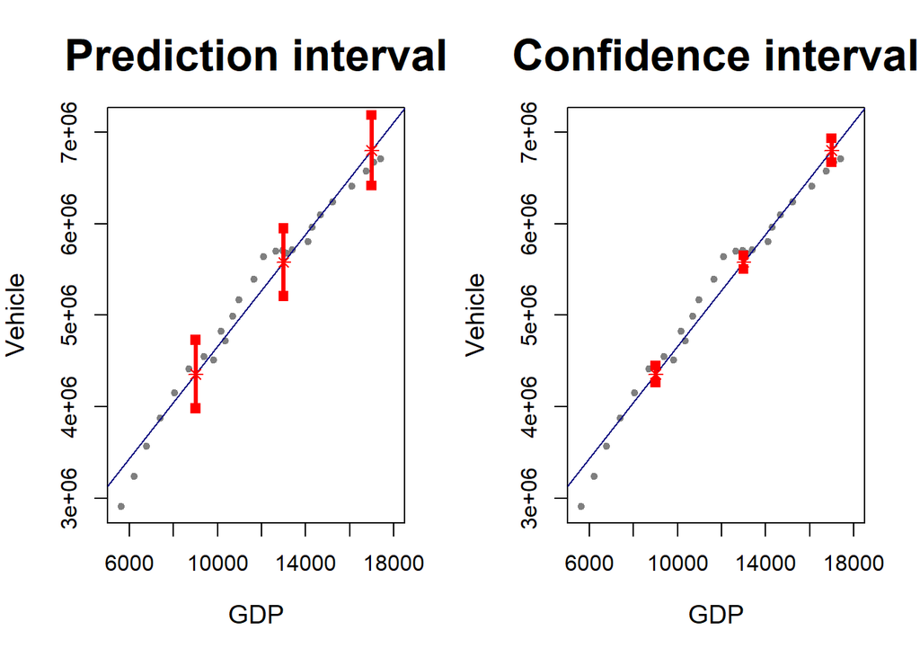

```r
#plotting
fit=PI[,1]
PI.low=PI[,2]
PI.high=PI[,3]

CI.low=CI[,2]
CI.high=CI[,3]

xx.test=c(9000,13000,17000)

par(mfrow=c(1,2))#把畫布分開(列，欄)

#plot PI

plot(Vehicle~GDP,data=veh,pch=20,col="gray50",
     main="Prediction interval",xlab="GDP",ylab="Vehicle",
     xlim=c(5500,18000),ylim=c(2900000,7100000),cex.main=2,cex.lab=1.2)

abline(RESULTS,col="navy")
for(i in 1:length(xx.test)){
  lines(c(xx.test[i],xx.test[i]),c(PI.low[i],PI.high[i]),col="red",lwd=3)
  points(xx.test[i],PI.low[i],col="red",pch=15)
  points(xx.test[i],PI.high[i],col="red",pch=15)
  points(xx.test[i],fit[i],col="red",pch=8)
}

#plot CI
plot(Vehicle~GDP,data=veh,pch=20,col="gray50",
     main="Confidence interval",xlab="GDP",ylab="Vehicle",
     xlim=c(5500,18000),ylim=c(2900000,7100000),cex.main=2,cex.lab=1.2)

abline(RESULTS,col="navy")
for(i in 1:length(xx.test)){
  lines(c(xx.test[i],xx.test[i]),c(CI.low[i],CI.high[i]),col="red",lwd=3)
  points(xx.test[i],CI.low[i],col="red",pch=15)
  points(xx.test[i],CI.high[i],col="red",pch=15)
  points(xx.test[i],fit[i],col="red",pch=8)
}
```

### 診斷

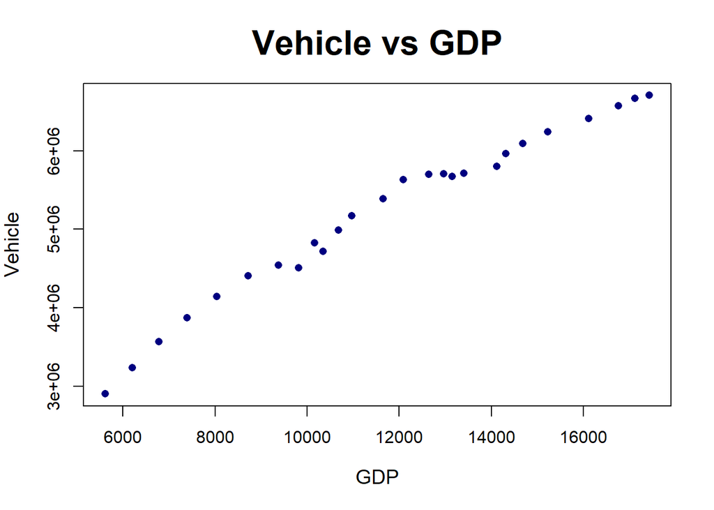

```r
#draw the scatter plot
##y vs x
plot(Vehicle~GDP,pch=16,cex=1,col="navy",
     main="Vehicle vs GDP",xlab="GDP",ylab="Vehicle",cex.main=2,cex.lab=1.2)
```

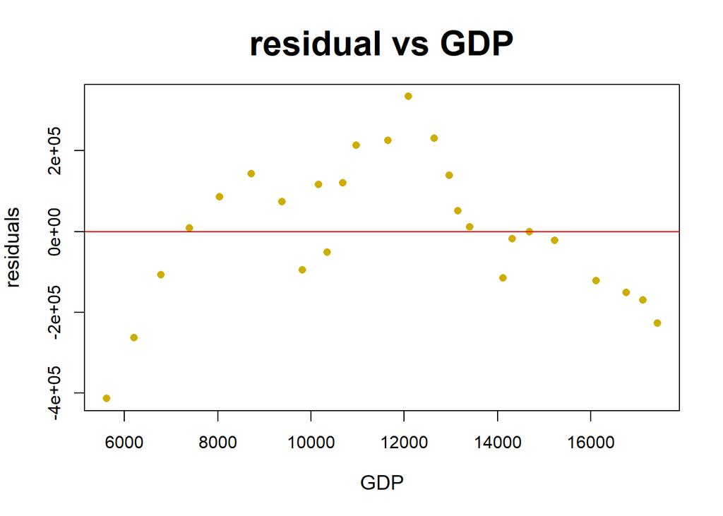

```r
#residuals vs x
res=RESULTS$res
plot(res~GDP,pch=16,cex=1,col="gold3",
     main="residual vs GDP",xlab="GDP",ylab="residuals",
     cex.main=2,cex.lab=1.2)

abline(h=0,col="red")
```

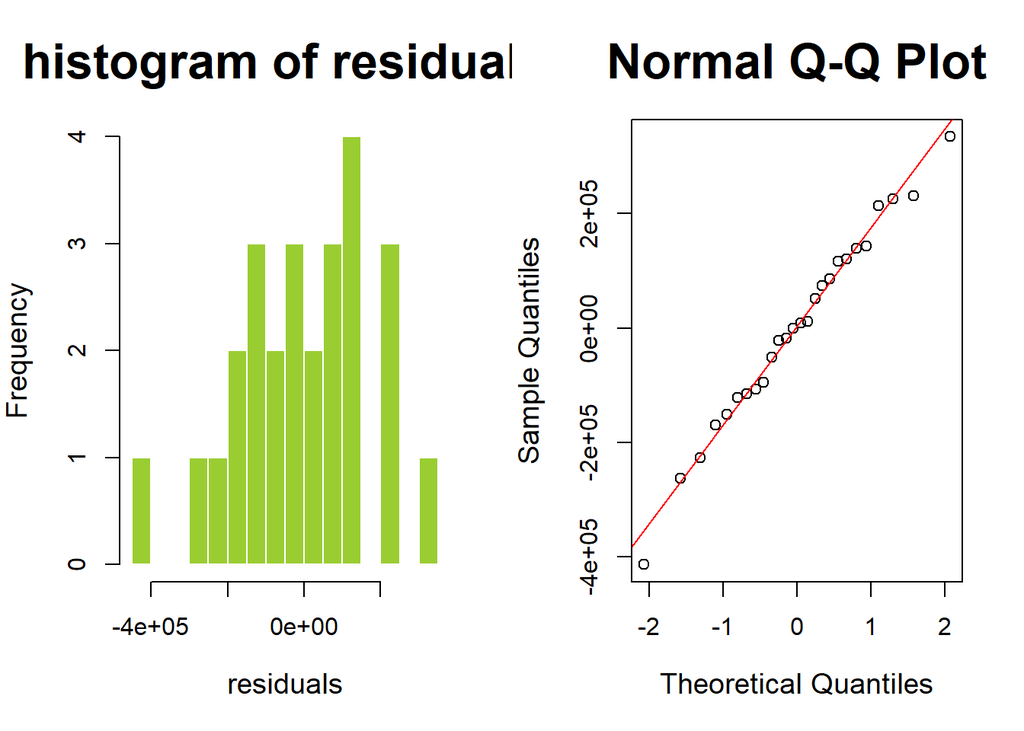

```r
#histogram of residuals
par(mfrow=c(1,2))

hist(res,breaks=20,border="white",col="olivedrab3",
     main="histogram of residuals", xlab="residuals",
     cex.main=2,cex.lab=1.2)

#qqplot
qqnorm(res,cex.main=2,cex.lab=1.2)
qqline(res,col="red")
```

by the histogram we can se that it is almost normal distribution and do not have outlier or extreme skewed, so as the qq-plot  
and we assume that two variable are independent